# Backscatter from NIR Illuminator

Ideally no light would be directly transmitted from the illuminator to the camera. Is this the case?

At JH request, on 24 Aug 2015 AT collected camera frames reresenting:

- white reference sample, illuminator on,
- dark reference sample, illuminator on,
- dark reference sample, illuminator off.

Turned out dat files were corrupt due to pointer shenanigans.

RD repeated data collection process 2 Sept 2015. He noted that it was "bloody hard to line up to the dark slot". I had imagined the lining up process as an essential set up step and a precursor to testing the backscatter. Obviously this is a poor assumption. That the camera and slit are not optimally aligned makes what follows susceptible to small changes in alignment.

# What does the data look like?

Lets start by taking a look at the data RD collected Sept 2, 2015:

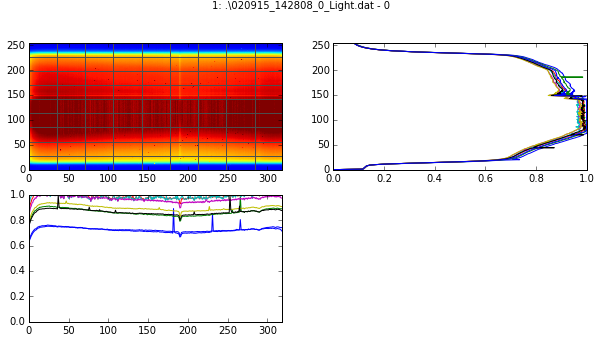

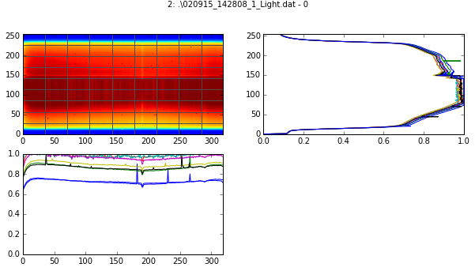

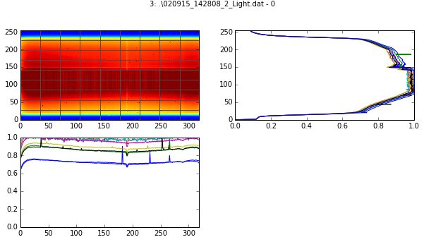

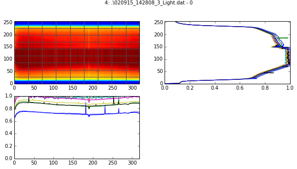

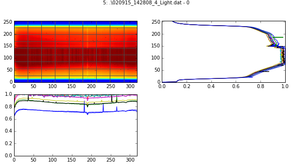

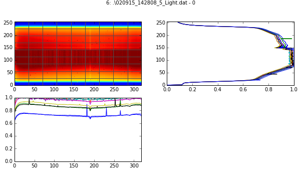

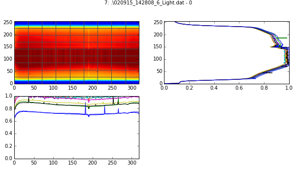

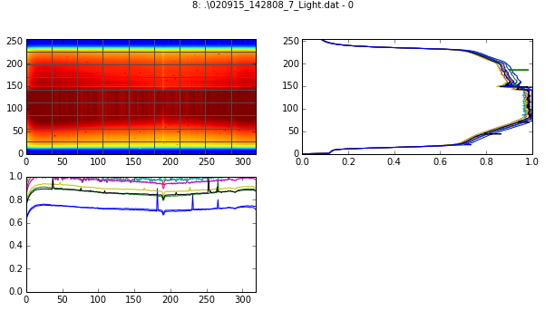

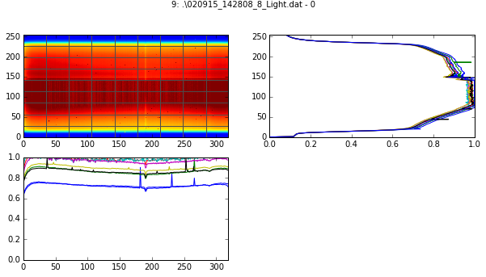

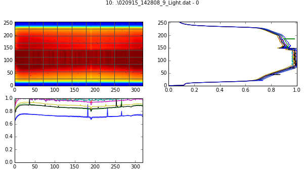

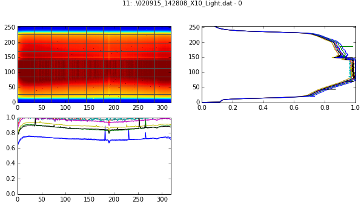

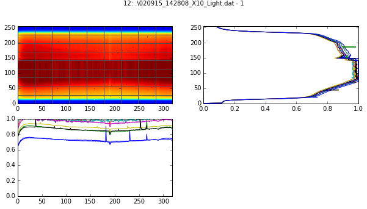

[28 more figures not shown]

```python
%pylab inline
pylab.rcParams['figure.figsize'] = (10, 5)
import backscatter as B
from glob import glob
R = []
for fn in glob('./020915_*.dat'):
    frames = B.read_dat(fn)
    for rep in range(frames.shape[2]):
        R.append(frames[:,:,rep])
        B.show_image(R[-1], title='%i: %s - %i' % (len(R),fn,rep))
```

Some observations:

- large number of bad pixels. More than on the last camera? MR dosn't think so, but is going to check with the manufacturer.
- lots of saturated pixels in white reference image!
- repeatability looks good. I'll quantify how good below.
- white reference images indicate 5 or 10% more illumination at the ends of the illumintor compared to the middle. Probably due to reflections from end walls. Perhaps these should have been painted black? They will mess with the incident light directional distribution as well.
- why (for the most part) is there a lower limit to reflectance?

# How repeatable are pixel values?

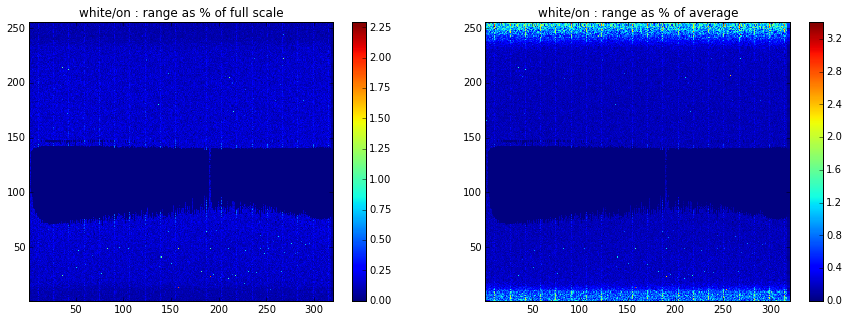

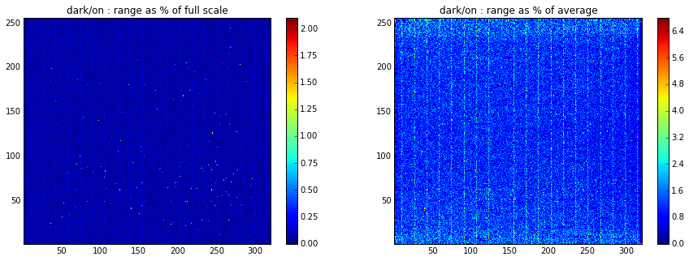

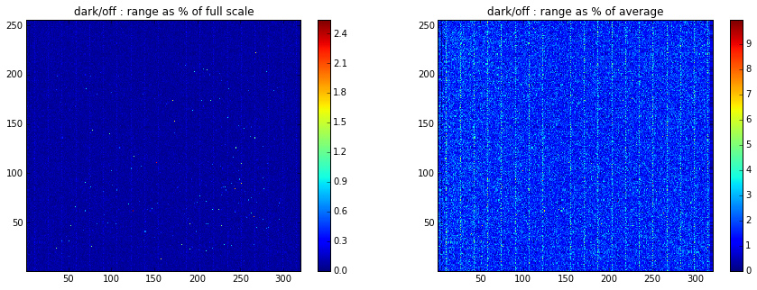

```python
pylab.rcParams['figure.figsize'] = (15, 5)
# frames 1--20 are of white ref, lamps on
def plot_range(frames, lbl):
    W = numpy.dstack(frames).astype(float)
    W[W==0]=1
    subplot(121)
    pcolor((W.max(axis=2)-W.min(axis=2))/4095.*100)
    axis((1,320,1,256))
    colorbar()
    title('%s : range as %% of full scale' % lbl)
    subplot(122)
    pcolor((W.max(axis=2)-W.min(axis=2))/W.mean(axis=2)*100)
    axis((1,320,1,256))
    colorbar()
    title('%s : range as %% of average' % lbl)
    show()
plot_range(R[0:20], 'white/on')
# frames 21--30 are of dark ref, lamps on
plot_range(R[20:30], 'dark/on')
# frames 31--40 are of dark ref, lamps off
plot_range(R[30:40], 'dark/off')
```

Repeatability is very good. Typically less than 1% f.s.

The region of very low variability in the white ref imagery is probably a consequence od saturation.

I wonder what causes the stripy artefacts? Maybe the sensor is composite silicon???

# Bad pixels?

```
(0, 1.0, 0, 1.0)
```

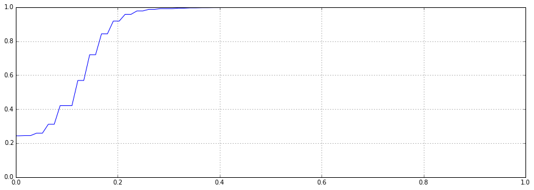

```python
# use the number of pixels in the white ref images with variation >range_crit% as a bad pixel count
W = numpy.dstack(R[0:20]).astype(float)
V = (W.max(axis=2)-W.min(axis=2))/4095.*100
from scipy.stats import cumfreq
cdf = cumfreq(V.reshape((-1)), 200)
#print(cdf)
plot(linspace(cdf[1],cdf[1]+200*cdf[2],200), cdf[0]/(320*256))
grid()
axis((0,1.,0,1.))
```

```python
range_crit = 0.35
nbadpixels = count_nonzero(V>range_crit)
print(nbadpixels)
```

```
330
```

```python
# where are these bad pixels?
#print(argwhere(V>range_crit))
```

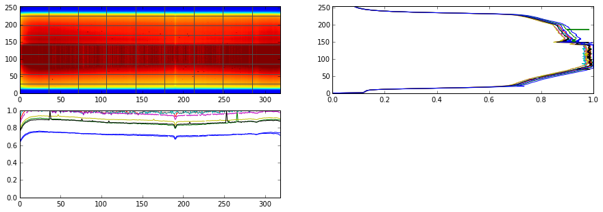

```python
# if removed what does the data look like
B.show_image(ma.masked_where(V>range_crit,(R[0].astype(float))))
```

Removing high variance pixels cleans things up a bit, but doesn't get rid of all the spikes. Presumably these are pixels having substantially different characteristics compared to their neighbours, but otherwise stable.

# Backscattered light

Assuming the dark reference reflects no light, backscattered light (light reaching the camera directly from the illuminator) is the difference between what the camera sees when targeting the dark reference with and without the illuminator lamps on.

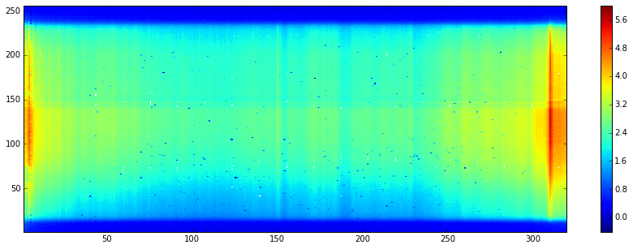

```python
# backscattered light % relative to full scale
W = ma.masked_where(V>range_crit, dstack(R[0:20]).mean(axis=2))
D = ma.masked_where(V>range_crit, dstack(R[20:30]).mean(axis=2))
DD = ma.masked_where(V>range_crit, dstack(R[30:40]).mean(axis=2))
pcolor((D-DD)/4095.*100)
axis((1,320,1,256))
colorbar();
```

```
(2.7688038478760126, 0.62644375595673751)
```

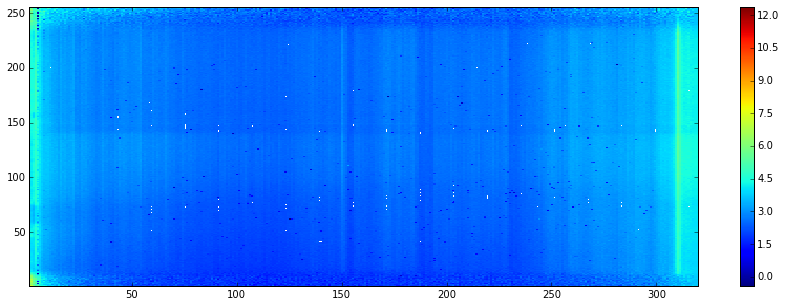

```python
# backscattered light % relative to white ref
M = (D-DD)/W*100
pcolor(M)
print(M.mean(), M.std())
axis((1,320,1,256))
colorbar();
```

Spectrally the backscattered light is similar to that relfected from the white reference. This will *NOT* be true of light reflected from wood and will introduce error in chemometric predictions from edge pixels.

# Conclusions